# Breast Cancer Diagnostic Report: XGBoost Analysis

Efe Mit

2025-12-19

# 1. Introduction

This report presents a comprehensive analysis of the **Breast Cancer Wisconsin (Original)** dataset using the **XGBoost (Extreme Gradient Boosting)** machine learning algorithm.

Our primary objective is to build a robust classification model to distinguish between **Benign** and **Malignant** tumors and to visualize the underlying decision-making process of the algorithm.

# 2. Data Preparation

We utilize the cleaned dataset (`cleaned_breast_cancer.csv`) where missing values have been handled and the target variable has been binary encoded (0 = Benign, 1 = Malignant).

### 2.1. Loading and Matrix Conversion

XGBoost requires data to be converted into a `xgb.DMatrix` format for optimized computation.

```r
# Load the cleaned dataset
# Ensure 'cleaned_breast_cancer.csv' is in your working directory from the previous step
dataset <- read.csv("cleaned_breast_cancer.csv")

# Split Data into Training (75%) and Test (25%) Sets
set.seed(123)
split = sample.split(dataset$Class, SplitRatio = 0.75)
training_set = subset(dataset, split == TRUE)
test_set = subset(dataset, split == FALSE)

# Convert to XGBoost Matrix Format
# Features: All columns except the last one (Class)
# Label: The last column (Class)
dtrain <- xgb.DMatrix(data = as.matrix(training_set[, -ncol(training_set)]),
                      label = training_set$Class)

dtest <- xgb.DMatrix(data = as.matrix(test_set[, -ncol(test_set)]),
                     label = test_set$Class)
```

# 3. Model Training

We train the XGBoost classifier with the following parameters designed to prevent overfitting while maximizing accuracy: * **Objective:** Binary Logistic (for 0/1 classification). * **Max Depth:** 6 (limits the complexity of individual trees). * **Rounds:** 50 (number of boosting iterations).

```r
# Define Hyperparameters
params <- list(
  objective = "binary:logistic",
  eval_metric = "error",
  eta = 0.1,
  max_depth = 6
)

# Train the Model
xgb_model <- xgb.train(
  params = params,
  data = dtrain,
  nrounds = 50,
  watchlist = list(train = dtrain, test = dtest),
  print_every_n = 10,
  verbose = 0 # Keep the report output clean
)
```

# 4. Quantitative Evaluation

### 4.1. Accuracy Calculation

We test the model’s performance on the unseen data (Test Set).

```r
# Predict probabilities
pred_probs <- predict(xgb_model, newdata = dtest)

# Convert probabilities to binary class (Threshold = 0.5)
y_pred <- ifelse(pred_probs > 0.5, 1, 0)

# Create Confusion Matrix
cm <- table(Actual = test_set$Class, Predicted = y_pred)

# Calculate Accuracy
accuracy <- sum(diag(cm)) / sum(cm)
cat("Model Accuracy:", round(accuracy * 100, 2), "%")
```

```
## Model Accuracy: 95.32 %
```

### 4.2. Confusion Matrix Visualization

The heatmap below illustrates the classification performance. * **0:** Benign (Harmless) * **1:** Malignant (Cancerous)

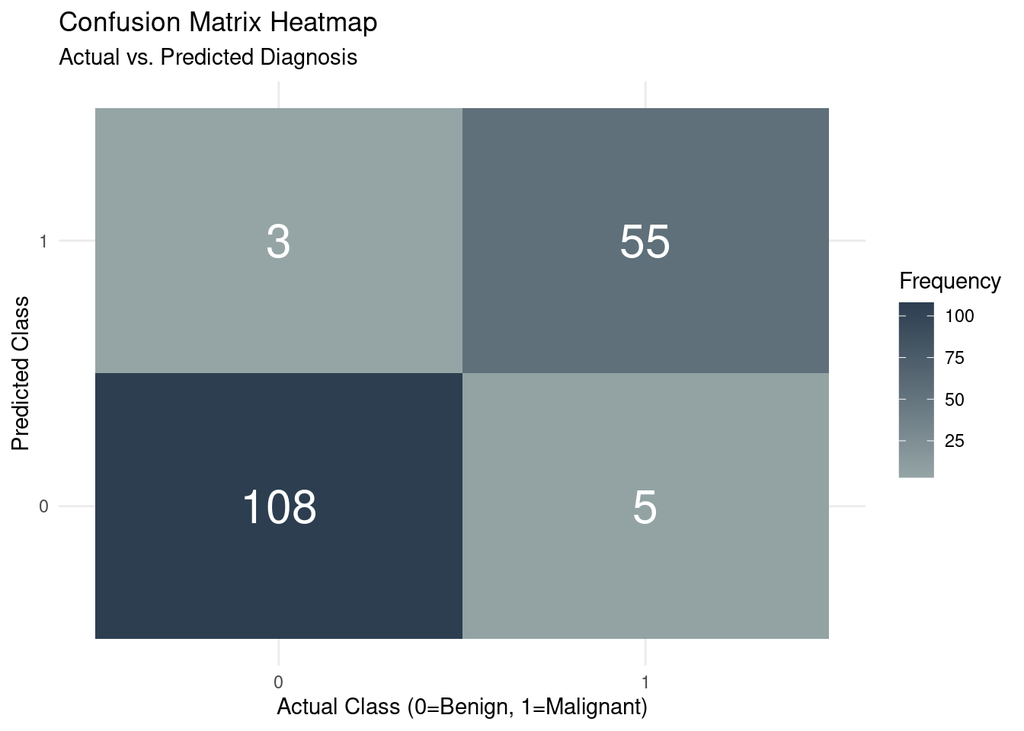

```r
# Prepare data for ggplot
cm_df <- as.data.frame(cm)
colnames(cm_df) <- c("Actual", "Predicted", "Frequency")

# Plot Heatmap
ggplot(data = cm_df, aes(x = Actual, y = Predicted, fill = Frequency)) +
  geom_tile() +
  geom_text(aes(label = Frequency), color = "white", size = 8) +
  scale_fill_gradient(low = "#95a5a6", high = "#2c3e50") +
  theme_minimal() +
  labs(title = "Confusion Matrix Heatmap",
       subtitle = "Actual vs. Predicted Diagnosis",
       x = "Actual Class (0=Benign, 1=Malignant)",
       y = "Predicted Class")
```

### 4.3. Feature Importance

Which biological features are most critical for the diagnosis? XGBoost calculates the “Gain” (importance) for each feature.

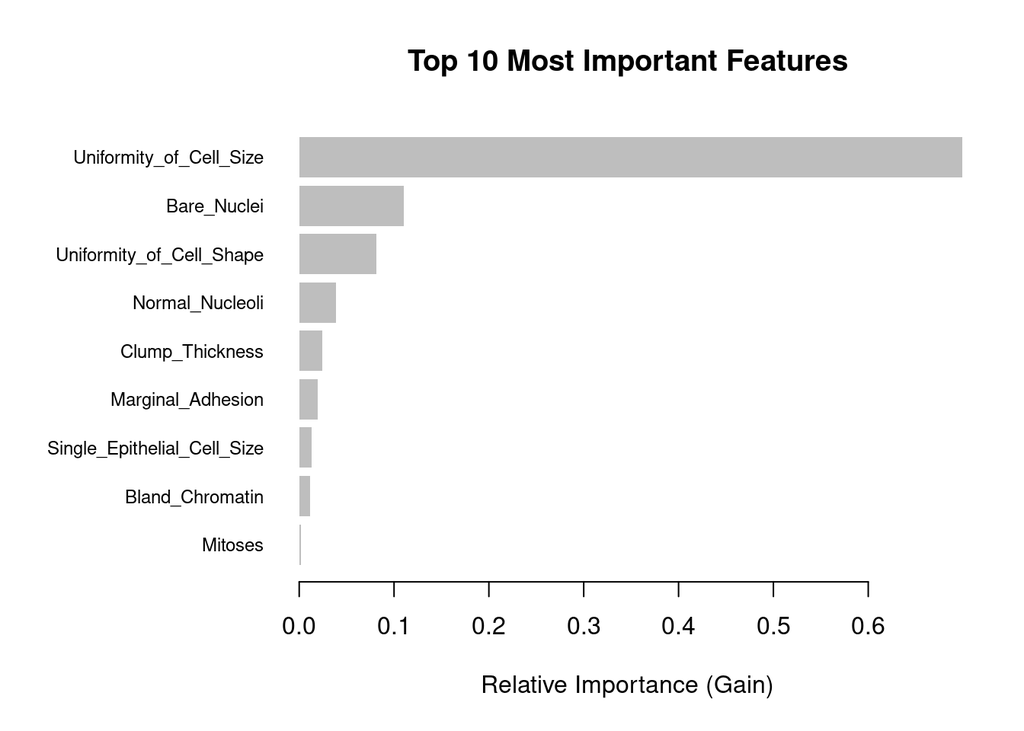

```r
# Compute Importance
importance_matrix <- xgb.importance(model = xgb_model)

# Plot Top 10 Features
xgb.plot.importance(importance_matrix, top_n = 10,
                    main = "Top 10 Most Important Features",
                    xlab = "Relative Importance (Gain)")
```

# 5. Advanced Visualizations

### 5.1. Visualization of Decision Logic (The “Brain”)

XGBoost consists of many decision trees. Below, we visualize the **first tree** in the ensemble. This diagram reveals the exact threshold values used by the model to split the patients.

- **Nodes:** Show the feature and the split condition (e.g., `Uniformity_of_Cell_Size < 3.5`).
- **Leaves:** Show the leaf value (contribution to the final score).

```r
# Plot the first tree (Tree index 0)
# This requires the 'DiagrammeR' package (loaded in setup)
xgb.plot.tree(model = xgb_model, trees = 0, plot_width = 900, plot_height = 600)
```

[interactive chart not shown]

### 5.2. Cluster Analysis: Size vs. Shape (Jitter Plot)

Since the dataset uses integer values (1-10), a standard scatter plot would cause points to overlap, hiding the true density. We use a **“Jitter Plot”** combined with density contours to visualize where Benign vs. Malignant cases cluster.

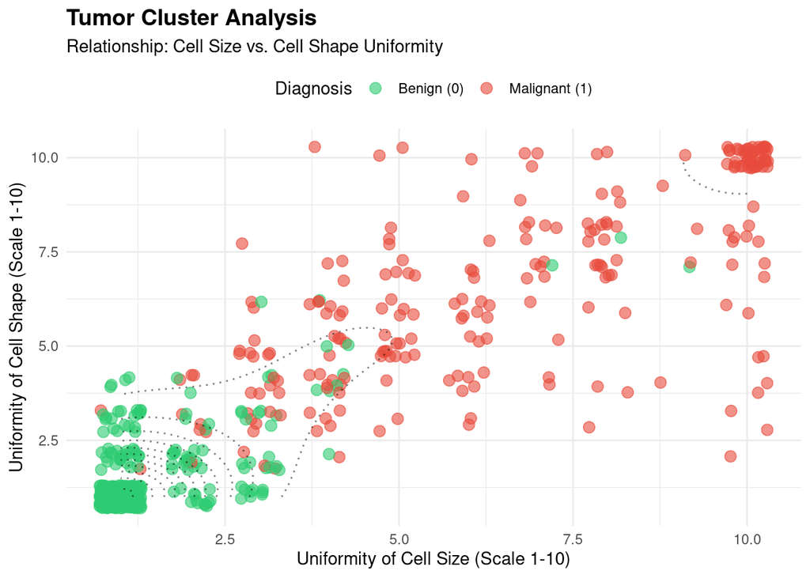

```r
# Jitter Plot with Density Contours
ggplot(dataset, aes(x = Uniformity_of_Cell_Size, y = Uniformity_of_Cell_Shape, color = as.factor(Class))) +

  # Add Jitter Points (Transparency added to see overlaps)
  geom_jitter(width = 0.3, height = 0.3, size = 3, alpha = 0.6) +

  # Add Density Contours (The "circles" showing high density areas)
  geom_density_2d(alpha = 0.5, color = "black", linetype = "dotted") +

  # Custom Colors and Labels
  scale_color_manual(values = c("#2ecc71", "#e74c3c"),
                     name = "Diagnosis",
                     labels = c("Benign (0)", "Malignant (1)")) +

  # Titles and Theme
  labs(title = "Tumor Cluster Analysis",
       subtitle = "Relationship: Cell Size vs. Cell Shape Uniformity",
       x = "Uniformity of Cell Size (Scale 1-10)",
       y = "Uniformity of Cell Shape (Scale 1-10)") +

  theme_minimal() +
  theme(legend.position = "top",
        plot.title = element_text(face = "bold", size = 14))
```

# 6. Conclusion

The XGBoost model successfully classified the breast cancer dataset with high accuracy.